# Stock Price Analysis of Top 5 US Custodian Banks from 2008 - 2018

### Hypothesis Testing and Confidence Intervals

**$$Definitions\ of\ Notation\ Used:$$** **$$H_O: Null\ Hypothesis$$** **$$H_1: Alternative\ Hypothesis$$** **$$\mu_{_s}: Stock\ Return\ population \ mean$$** **$$\mu_{_i}: Index\ Return\ population\ mean$$** **$$\alpha: level\ of\ significance\ 5\%$$** **$$P: P-Value$$**

##### Two Tailed Test

- Are the stocks returns the same as the index return?

**$$Mathematical\ Statement:$$** **$$H_0: \mu_{_s} - \mu_{_i} = 0$$** **$$H_1: \mu_{_s} - \mu_{_i} \neq 0$$**

#### One Tailed Tests

###### Lower or Left Tailed Test

- Are the stock's returns less than the index?

**$$Mathematical\ Statement:$$** **$$H_0: \mu_{_s} - \mu_{_i} \geq 0$$** **$$H_1: \mu_{_s} - \mu_{_i} \ < 0$$**

###### Upper or Right Tailed Test

- Are the stock's returns greater than the index?

**$$Mathematical\ Statement:$$** **$$H_0: \mu_{_s} - \mu_{_i} \leq 0$$** **$$H_1: \mu_{_s} - \mu_{_i} \ > 0$$**

###### Probablity Value and Significance Level

**$$Mathematical\ Statement:$$** **$$H_0: P \geq \alpha$$** **$$H_1: P \ < \alpha$$**

#### Symbol BK : BNY Mellon

```python
import researchpy as rp

def tt_BK():
    #results of population percentage change between stk/idx price data
    des, res = rp.ttest(returns['BK'], returns['^GSPC'],
                            paired= True)

    print(des, '\n')
    print(res, '\n')

    #critical t for significance level of .05 and degree of freedom of 2516 (n-1)
    tcritical = st.distributions.t.ppf(1-.05/2,2516)
    print('critical t: %.5f' % tcritical)

    #t-statistic and p-value for a paired two tailed test
    paired_sample = st.ttest_rel(returns['BK'], returns['^GSPC'])
    print('t-statistic: %.5f,  two tailed p-value: %.5f'% paired_sample)

    return
tt_BK()
```

```
  Variable       N      Mean        SD        SE  95% Conf.  Interval
0       BK  2516.0  0.000480  0.020245  0.000404  -0.000312  0.001271
1    ^GSPC  2516.0  0.000461  0.010483  0.000209   0.000051  0.000871
2     diff  2516.0  0.000019  0.014415  0.000287  -0.000545  0.000582

                   Paired samples t-test    results
0             Difference (BK - ^GSPC) =      0.0000
1                  Degrees of freedom =   2515.0000
2                                   t =      0.0653
3               Two side test p value =      0.9479
4  Mean of BK > mean of ^GSPC p value =      0.5260
5  Mean of BK < mean of ^GSPC p value =      0.4740
6                           Cohen's d =      0.0013
7                           Hedge's g =      0.0013
8                       Glass's delta =      0.0009
9                                   r =      0.0013

critical t: 1.96091
t-statistic: 0.06535,  two tailed p-value: 0.94790
```

###### T TEST

- ###### Two-sided Test:
  - Our results indicate "We Fail to Reject the Null Hypothesis"
  - The p value of 0.9479, indicates there is a high probabilty 94% our returns are equal and 6% probability are returns are not equal; in addition, our T-statistic .0653 falls inside the accepance region 1.96091 and -1.96091
  - This indicates stock returns and index returns are fairly the same
  - The percent change difference between BK and SP500 is so low that the difference is nearly zero .000019 and hardly noticeable
  - A portfolio manager would boast about having returns the same as SP500; evidence seems to suggest it, since the difference in returns isn't noticeable
- ###### One-sided Test: Upper or Right Tailed
  - Our results indicate "We Fail to Reject the Null Hypothesis"
  - The p value of .52605, indicates there is a probabilty of 52.6% stock returns will be greater than the index returns; in addition, our T-statistic .0653 falls inside the acceptance region 1.96091
- ###### One-sided Test: Lower or Left Tailed
  - Our results indicate "We Fail to Reject the Null Hypothesis"
  - The p value of .47395, indicates there is a probabilty of 47.4% stock returns will be less than the index returns; in addition, our T-statistic .0653 falls inside the acceptance region -1.96091
- ###### Based on our one sided tests 52.605% of the time stocks returns are greater than the index and the 47.395% less than the index, but the overall average over 10 year period is roughly "0"

```
Sample Confidence Interval for Difference in Means: -0.00203 0.00095

Sample Mean: -0.00055

Sample Std Deviation: 0.00076
```

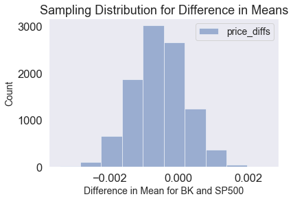

```python
def data_BK():
    #sampling distribution for difference in means to check for normality in the data for testing
    np.random.seed(42)
    sample_data = returns.sample(252)

    stk_price, idx_price, price_diffs = [],[],[]

    for _ in range(10000):
        price_diffs_sample = sample_data.sample(252, replace=True)
        stk_price_mean = price_diffs_sample['BK'].mean()
        idx_price_mean = price_diffs_sample['^GSPC'].mean()
        stk_price.append(stk_price_mean)
        idx_price.append(idx_price_mean)
        price_diffs.append(stk_price_mean - idx_price_mean)

    #confidence interval/standard deviation/means for the sampling distribution for difference in means
    print('Sample Confidence Interval for Difference in Means: %.5f'% np.percentile(price_diffs, 2.5),
          '%.5f' % np.percentile(price_diffs, 97.5),'\n')
    print('Sample Mean: %.5f'% np.mean(price_diffs),'\n')
    print('Sample Std Deviation: %.5f'% np.std(price_diffs))

    #plotted histogram of price_diffs
    plt.hist(price_diffs, alpha = 0.5, label='price_diffs');
    plt.title('Sampling Distribution for Difference in Means')
    plt.xlabel('Difference in Mean for BK and SP500', fontsize = 14)
    plt.ylabel('Count', fontsize = 14)
    plt.legend(fontsize = 14);

    return
data_BK()
```

###### Sampled Data: BK Return vs SP500 Return

- Our data is normally distributed
- Difference in mean does lie near zero
- The lower level is -0.00203
- The Upper level is 0.00095
- 95% Confidence Interval: -0.00055 ± 0.0015 (-0.00203 to 0.00095)
- "With 95% confidence the population mean is between -00203 and 0.00095, based on 252 samples"
- Based on our sample data "We Fail to Reject the Null Hypothesis"
- The results aren't significant:our stock's return is different from the index; because the difference is insignificant and unnoticeable, unless you're looking for a precise zero
- A portfolio manager based on this data would advertise the stocks return is inline with the index returns over the 10 year period

#### Symbol C : Citigroup

```python
def tt_C():
    #results of population percentage change between stk/idx price data
    des, res = rp.ttest(returns['C'], returns['^GSPC'],
                            paired= True)

    print(des, '\n')
    print(res, '\n')

    #critical t for significance level of .05 and degree of freedom of 2516 (n-1)
    tcritical = st.distributions.t.ppf(1-.05/2,2516)
    print('critical t: %.5f' % tcritical)

    #t-statistic and p-value for a paired two tailed test
    paired_sample = st.ttest_rel(returns['C'], returns['^GSPC'])
    print('t-statistic: %.5f,  two tailed p-value: %.5f'% paired_sample)

    return
tt_C()
```

```
  Variable       N      Mean        SD        SE  95% Conf.  Interval
0        C  2516.0  0.000416  0.031399  0.000626  -0.000811  0.001644
1    ^GSPC  2516.0  0.000461  0.010483  0.000209   0.000051  0.000871
2     diff  2516.0 -0.000044  0.025889  0.000516  -0.001056  0.000968

                  Paired samples t-test    results
0             Difference (C - ^GSPC) =     -0.0000
1                 Degrees of freedom =   2515.0000
2                                  t =     -0.0860
3              Two side test p value =      0.9315
4  Mean of C > mean of ^GSPC p value =      0.4657
5  Mean of C < mean of ^GSPC p value =      0.5343
6                          Cohen's d =     -0.0017
7                          Hedge's g =     -0.0017
8                      Glass's delta =     -0.0014
9                                  r =      0.0017

critical t: 1.96091
t-statistic: -0.08598,  two tailed p-value: 0.93149
```

###### T TEST

- ###### Two-sided Test:
  - Our results indicate "We Fail to Reject the Null Hypothesis"
  - The p value of 0.9315, indicates there is a high probabilty 93.1% our returns are equal and 6.9% probability are returns are not equal; in addition, our T-statistic -.0860 falls inside the accepance region 1.96091 and -1.96091
  - This indicates stock returns and index returns are fairly the same
  - The percent change difference between C and SP500 is so low that the difference is nearly zero -0.000044 and hardly noticeable
  - A portfolio manager would boast about having returns the same as SP500; evidence seems to suggest it, since the difference in returns isn't noticeable
- ###### One-sided Test: Upper or Right Tailed
  - Our results indicate "We Fail to Reject the Null Hypothesis"
  - The p value of 0.4657, indicates there is a probabilty of 46.5% stock returns will be greater than the index returns; in addition, our T-statistic -.0860 falls inside the acceptance region 1.96091
- ###### One-sided Test: Lower or Left Tailed
  - Our results indicate "We Fail to Reject the Null Hypothesis"
  - The p value of 0.5343, indicates there is a probabilty of 53.4% stock returns will be less than the index returns; in addition, our T-statistic -.0860 falls inside the acceptance region -1.96091
- ###### Based on our one sided tests 46.57% of the time stocks returns are greater than the index and 53.43% less than the index, but the overall average over 10 year period is roughly "0"

```
Sample Confidence Interval for Difference in Means: -0.00238 0.00160

Sample Mean: -0.00039

Sample Std Deviation: 0.00102
```

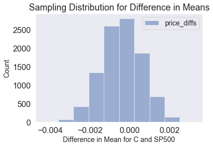

```python
def data_C():
    #sampling distribution for difference in means to check for normality in the data for testing
    np.random.seed(42)
    sample_data = returns.sample(252)

    stk_price, idx_price, price_diffs = [],[],[]

    for _ in range(10000):
        price_diffs_sample = sample_data.sample(252, replace=True)
        stk_price_mean = price_diffs_sample['C'].mean()
        idx_price_mean = price_diffs_sample['^GSPC'].mean()
        stk_price.append(stk_price_mean)
        idx_price.append(idx_price_mean)
        price_diffs.append(stk_price_mean - idx_price_mean)

    #confidence interval/standard deviation/means for the sampling distribution for difference in means
    print('Sample Confidence Interval for Difference in Means: %.5f'% np.percentile(price_diffs, 2.5),
          '%.5f' % np.percentile(price_diffs, 97.5),'\n')
    print('Sample Mean: %.5f'% np.mean(price_diffs),'\n')
    print('Sample Std Deviation: %.5f'% np.std(price_diffs))

    #plotted histogram of price_diffs
    plt.hist(price_diffs, alpha = 0.5, label='price_diffs');
    plt.title('Sampling Distribution for Difference in Means')
    plt.xlabel('Difference in Mean for C and SP500', fontsize = 14)
    plt.ylabel('Count', fontsize = 14)
    plt.legend(fontsize = 14);

    return
data_C()
```

###### Sampled Data: C Return vs SP500 Return

- Our data is normally distributed
- Difference in mean does lie near zero
- The lower level is -0.00238
- The Upper level is 0.00160
- 95% Confidence Interval: -0.00039 ± 0.00199 (-0.00238 to 0.00160)
- "With 95% confidence the population mean is between -0.00238 and 0.00160, based on 252 samples"
- Based on our sample data "We Fail to Reject the Null Hypothesis"
- The results aren't significant:our stock's return is different from the index; because the difference is insignificant and unnoticeable, unless you're looking for a precise zero
- A portfolio manager based on this data would advertise the stocks return is inline with the index returns over the 10 year period

```python
def tt_JPM():
    #results of population percentage change between stk/idx price data
    des, res = rp.ttest(returns['JPM'], returns['^GSPC'],
                            paired= True)

    print(des, '\n')
    print(res, '\n')

    #critical t for significance level of .05 and degree of freedom of 2516 (n-1)
    tcritical = st.distributions.t.ppf(1-.05/2,2516)
    print('critical t: %.5f' % tcritical)

    #t-statistic and p-value for a paired two tailed test
    paired_sample = st.ttest_rel(returns['JPM'], returns['^GSPC'])
    print('t-statistic: %.5f,  two tailed p-value: %.5f'% paired_sample)

    return
tt_JPM()
```

```
  Variable       N      Mean        SD        SE  95% Conf.  Interval
0      JPM  2516.0  0.000787  0.022298  0.000445  -0.000085  0.001658
1    ^GSPC  2516.0  0.000461  0.010483  0.000209   0.000051  0.000871
2     diff  2516.0  0.000326  0.015932  0.000318  -0.000297  0.000949

                    Paired samples t-test    results
0             Difference (JPM - ^GSPC) =      0.0003
1                   Degrees of freedom =   2515.0000
2                                    t =      1.0263
3                Two side test p value =      0.3049
4  Mean of JPM > mean of ^GSPC p value =      0.8476
5  Mean of JPM < mean of ^GSPC p value =      0.1524
6                            Cohen's d =      0.0205
7                            Hedge's g =      0.0205
8                        Glass's delta =      0.0146
9                                    r =      0.0205

critical t: 1.96091
t-statistic: 1.02629,  two tailed p-value: 0.30486
```

###### T TEST

- ###### Two-sided Test:
  - Our results indicate "We Fail to Reject the Null Hypothesis"
  - The p value of 0.3049, indicates there is a probabilty 30.4% our returns are equal and 69.6% probability are returns are not equal; in addition, our T-statistic 1.0263 falls inside the accepance region 1.96091 and -1.96091
  - This indicates stock returns and index returns are fairly the same
  - The percent change difference between JPM and SP500 is so low that the difference is nearly zero 0.000326 and hardly noticeable
  - A portfolio manager would boast about having returns the same as SP500; evidence seems to suggest it, since the difference in returns isn't noticeable
- ###### One-sided Test: Upper or Right Tailed
  - Our results indicate "We Fail to Reject the Null Hypothesis"
  - The p value of 0.8476, indicates there is a probabilty of 84.7% stock returns will be greater than the index returns; in addition, our T-statistic 1.0263 falls inside the acceptance region 1.96091
- ###### One-sided Test: Lower or Left Tailed
  - Our results indicate "We Fail to Reject the Null Hypothesis"
  - The p value of 0.1524, indicates there is a probabilty of 15.3% stock returns will be less than the index returns; in addition, our T-statistic 1.0263 falls inside the acceptance region -1.96091
- ###### Based on our one sided tests 84.76% of the time stocks returns are greater than the index and 15.24% less than the index, but the overall average over 10 year period is roughly "0"

```
Sample Confidence Interval for Difference in Means: -0.00155 0.00134

Sample Mean: -0.00012

Sample Std Deviation: 0.00075
```

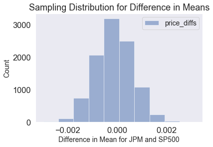

```python
def data_JPM():
    #sampling distribution for difference in means to check for normality in the data for testing
    np.random.seed(42)
    sample_data = returns.sample(252)

    stk_price, idx_price, price_diffs = [],[],[]

    for _ in range(10000):
        price_diffs_sample = sample_data.sample(252, replace=True)
        stk_price_mean = price_diffs_sample['JPM'].mean()
        idx_price_mean = price_diffs_sample['^GSPC'].mean()
        stk_price.append(stk_price_mean)
        idx_price.append(idx_price_mean)
        price_diffs.append(stk_price_mean - idx_price_mean)

    #confidence interval/standard deviation/means for the sampling distribution for difference in means
    print('Sample Confidence Interval for Difference in Means: %.5f'% np.percentile(price_diffs, 2.5),
          '%.5f' % np.percentile(price_diffs, 97.5),'\n')
    print('Sample Mean: %.5f'% np.mean(price_diffs),'\n')
    print('Sample Std Deviation: %.5f'% np.std(price_diffs))

    #plotted histogram of price_diffs
    plt.hist(price_diffs, alpha = 0.5, label='price_diffs');
    plt.title('Sampling Distribution for Difference in Means')
    plt.xlabel('Difference in Mean for JPM and SP500', fontsize = 14)
    plt.ylabel('Count', fontsize = 14)
    plt.legend(fontsize = 14);

    return
data_JPM()
```